# IODS-project

nuriiar

# Introduction to Open Data Science - Course Project

# About the project

```r
# This is a so-called "R chunk" where you can write R code.

date()
```

```
## [1] "Wed Dec 14 19:06:51 2022"
```

The text continues here. # The beginning was hectic, with a lot of information in different places of moodle, excercise and the book. I expect to at least learn how to navigate between github and desctop application for R or python, to be able to pull some freely available data. # also this excercise set 1 is confusing and very long. Most of the course participants are PhD students, who has got so much time for a single course? I have been doing some python courses before, and for me, just looking at some code chunks is not so useful, there is not much explanation of the syntax, what is %>% ? what is < - ? and so on. To learn to code, looking at codes does not help, you need to try and write one all the time. # https://nuriiar.github.io/IODS-project/

```r
date()
```

```
## [1] "Wed Dec 14 19:06:51 2022"
```

Here we go again…

#*opening relevant libraries*

#*reading the csv data set, looking at its structure and dimensions. It has 7 variables and 166 rows, one of the variables is a string variable with characters stored in it (gender) and 6 other variables are floats (double precision floats)*

lrn_csv <- read_csv(“lrn_analysis.csv”,col_names = TRUE) str(lrn_csv) dim(lrn_csv)

#*I Chose the variables for analysis: gender, age, attitude, and surf. The idea is to test how the emotions-related variables are associated with points students received at statistics exam, controlling for gender and age. Firstly, we explore the variables by summarising them, first, the variable points by gender with minimum max, average and standard deviation and then age, attitude, surf*

#summarise relations p <- ggpairs(learning2014, mapping = aes(col = gender), lower = list(combo = wrap(“facethist”, bins = 20))) + theme_bw() p

lrn_csv %>% group_by(gender) %>% summarise(min(points), max(points), mean(points), sd(points))

lrn_csv %>% summarise(min(age), max(age), mean(age), sd(age))

#*This helps to get to know who are the study participants. Students vary in age from 17 to 55 years, with an average at 25.5, and standard deviation of 7.77*

lrn_csv %>% summarise(min(attitude), max(attitude), mean(attitude), sd(attitude))

#*the attitude is an index for attitude towards statistics, a subjective measurement that takes a minimum value at 14 and maximum at 50, with a mean of 31.4 and standard deviation of 7.3*

lrn_csv %>% summarise(min(surf), max(surf), mean(surf), sd(surf))

#*surf is a composite variable based on likert scale variables (1-5 points) for opinion measurement from strongly disagree to strongly agree. The mean value is 2.8 with a standard deviation of 0.5. The questions concern subjective opinion related to interest in statistics course, feeling of whether the course is actually worth going to. I hypothesise that this variable reflects on inner motivation of student to complete the course, that may directly influence the final exam score. Given the formulation of sub-questions such as “There’s not much of the work here that I find interesting or relevant”, in general students are closer to agreeing with low interest in the course.*

#*Next is graphics. Getting the scatter plots of exam points against our independent variables to have a first glimpse of the association.*

lrn_csv %>% ggplot(aes(x = attitude, y = points)) + geom_point()

lrn_csv %>% ggplot(aes(x = surf, y = points)) + geom_point()

lrn_csv %>% ggplot(aes(x = age, y = points)) + geom_point()

#*regression. Fitting a linear regression models, introducing variables stepwise for points as dependent and our variables of interest: attitude and surf as independent, and then controlling also for gender and age.*

help(lm)

model1 <- lm(points ~ attitude, data = lrn_csv) summary(model1)

model2 <- lm(points ~ attitude + surf, data = lrn_csv) summary(model2)

model3 <- lm(points ~ attitude + surf + gender + age, data = lrn_csv) summary(model3)

## plotting the linear model with a line, checking model fit

qplot(attitude, points, data = lrn_csv) + geom_smooth(method = “lm”) plot(linear_attitude, which = c(1,2,5))

#*Discussion.*

```r
date()
```

```
## [1] "Wed Dec 14 19:06:51 2022"
```

Here we go again…

#*opening relevant libraries*

library(tidyverse) library(readr) library(dplyr) library(ggplot2)

#*reading the csv data set, looking at its structure and dimensions. It has 7 variables and 166 rows, one of the variables is a string variable with characters stored in it (gender) and 6 other variables are floats (double precision floats)*

lrn_csv <- read_csv(“lrn_analysis.csv”,col_names = TRUE) str(lrn_csv) dim(lrn_csv)

#*I Chose the variables for analysis: gender, age, attitude, and surf. The idea is to test how the emotions-related variables are associated with points students received at statistics exam, controlling for gender and age. Firstly, we explore the variables by summarising them, first, the variable points by gender with minimum max, average and standard deviation and then age, attitude, surf*

lrn_csv %>% group_by(gender) %>% summarise(min(points), max(points), mean(points), sd(points))

lrn_csv %>% summarise(min(age), max(age), mean(age), sd(age))

#*This helps to get to know who are the study participants. Students vary in age from 17 to 55 years, with an average at 25.5, and standard deviation of 7.77*

lrn_csv %>% summarise(min(attitude), max(attitude), mean(attitude), sd(attitude))

#*the attitude is an index for attitude towards statistics, a subjective measurement that takes a minimum value at 14 and maximum at 50, with a mean of 31.4 and standard deviation of 7.3*

lrn_csv %>% summarise(min(surf), max(surf), mean(surf), sd(surf))

#*surf is a composite variable based on likert scale variables (1-5 points) for opinion measurement from strongly disagree to strongly agree. The mean value is 2.8 with a standard deviation of 0.5. The questions concern subjective opinion related to interest in statistics course, feeling of whether the course is actually worth going to. I hypothesise that this variable reflects on inner motivation of student to complete the course, that may directly influence the final exam score. Given the formulation of sub-questions such as “There’s not much of the work here that I find interesting or relevant”, in general students are closer to agreeing with low interest in the course.*

#*Next is graphics. Getting the scatter plots of exam points against our independent variables to have a first glimpse of the association.*

lrn_csv %>% ggplot(aes(x = attitude, y = points)) + geom_point()

lrn_csv %>% ggplot(aes(x = surf, y = points)) + geom_point()

lrn_csv %>% ggplot(aes(x = age, y = points)) + geom_point()

#*regression. Fitting a linear regression models, introducing variables stepwise for points as dependent and our variables of interest: attitude and surf as independent, and then controlling also for gender and age.*

help(lm)

model1 <- lm(points ~ attitude, data = lrn_csv) summary(model1)

model2 <- lm(points ~ attitude + surf, data = lrn_csv) summary(model2)

model3 <- lm(points ~ attitude + surf + gender + age, data = lrn_csv) summary(model3)

#*Discussion.*

## Assignment 3

```r
#Opening relevant libraries

library(tidyverse)
```

```r
library(readr)
library(dplyr)
library(ggplot2)
```

```r
#reading the csv data set, looking at column names and structure. It has 35 variables and 370 rows. This dataset present merged results of questionnaire of two Portuguese schools on student achievement in math and Portuguese language class and alcohol consumption in secondary education. The data attributes include student grades, demographic, social and school related features and it was collected by using school reports and questionnaires. More on the dataset from: https://archive.ics.uci.edu/ml/datasets/Student+Performance

alc <- read_csv("alcohol.csv",col_names = TRUE)
colnames(alc)
```

```
##  [1] "school"     "sex"        "age"        "address"    "famsize"
##  [6] "Pstatus"    "Medu"       "Fedu"       "Mjob"       "Fjob"
## [11] "reason"     "guardian"   "traveltime" "studytime"  "schoolsup"
## [16] "famsup"     "activities" "nursery"    "higher"     "internet"
## [21] "romantic"   "famrel"     "freetime"   "goout"      "Dalc"
## [26] "Walc"       "health"     "failures"   "paid"       "absences"
## [31] "G1"         "G2"         "G3"         "alc_use"    "high_use"
```

```r
str(alc)
```

```
## spc_tbl_ [370 × 35] (S3: spec_tbl_df/tbl_df/tbl/data.frame)
##  $ school    : chr [1:370] "GP" "GP" "GP" "GP" ...
##  $ sex       : chr [1:370] "F" "F" "F" "F" ...
##  $ age       : num [1:370] 18 17 15 15 16 16 16 17 15 15 ...
##  $ address   : chr [1:370] "U" "U" "U" "U" ...
##  $ famsize   : chr [1:370] "GT3" "GT3" "LE3" "GT3" ...
##  $ Pstatus   : chr [1:370] "A" "T" "T" "T" ...
##  $ Medu      : num [1:370] 4 1 1 4 3 4 2 4 3 3 ...
##  $ Fedu      : num [1:370] 4 1 1 2 3 3 2 4 2 4 ...
##  $ Mjob      : chr [1:370] "at_home" "at_home" "at_home" "health" ...
##  $ Fjob      : chr [1:370] "teacher" "other" "other" "services" ...
##  $ reason    : chr [1:370] "course" "course" "other" "home" ...
##  $ guardian  : chr [1:370] "mother" "father" "mother" "mother" ...
##  $ traveltime: num [1:370] 2 1 1 1 1 1 1 2 1 1 ...
##  $ studytime : num [1:370] 2 2 2 3 2 2 2 2 2 2 ...
##  $ schoolsup : chr [1:370] "yes" "no" "yes" "no" ...
##  $ famsup    : chr [1:370] "no" "yes" "no" "yes" ...
##  $ activities: chr [1:370] "no" "no" "no" "yes" ...
##  $ nursery   : chr [1:370] "yes" "no" "yes" "yes" ...
##  $ higher    : chr [1:370] "yes" "yes" "yes" "yes" ...
##  $ internet  : chr [1:370] "no" "yes" "yes" "yes" ...
##  $ romantic  : chr [1:370] "no" "no" "no" "yes" ...
##  $ famrel    : num [1:370] 4 5 4 3 4 5 4 4 4 5 ...
##  $ freetime  : num [1:370] 3 3 3 2 3 4 4 1 2 5 ...
##  $ goout     : num [1:370] 4 3 2 2 2 2 4 4 2 1 ...
##  $ Dalc      : num [1:370] 1 1 2 1 1 1 1 1 1 1 ...
##  $ Walc      : num [1:370] 1 1 3 1 2 2 1 1 1 1 ...
##  $ health    : num [1:370] 3 3 3 5 5 5 3 1 1 5 ...
##  $ failures  : num [1:370] 0 0 2 0 0 0 0 0 0 0 ...
##  $ paid      : chr [1:370] "no" "no" "yes" "yes" ...
##  $ absences  : num [1:370] 5 3 8 1 2 8 0 4 0 0 ...
##  $ G1        : num [1:370] 2 7 10 14 8 14 12 8 16 13 ...
##  $ G2        : num [1:370] 8 8 10 14 12 14 12 9 17 14 ...
##  $ G3        : num [1:370] 8 8 11 14 12 14 12 10 18 14 ...
##  $ alc_use   : num [1:370] 1 1 2.5 1 1.5 1.5 1 1 1 1 ...
##  $ high_use  : logi [1:370] FALSE FALSE TRUE FALSE FALSE FALSE ...
##  - attr(*, "spec")=
##   .. cols(
##   ..   school = col_character(),
##   ..   sex = col_character(),
```

[output cut: 20 more lines]

```
##   ..   freetime = col_double(),
##   ..   goout = col_double(),
##   ..   Dalc = col_double(),
##   ..   Walc = col_double(),
##   ..   health = col_double(),
##   ..   failures = col_double(),
##   ..   paid = col_character(),
##   ..   absences = col_double(),
##   ..   G1 = col_double(),
##   ..   G2 = col_double(),
##   ..   G3 = col_double(),
##   ..   alc_use = col_double(),
##   ..   high_use = col_logical()
##   .. )
##  - attr(*, "problems")=<externalptr>
```

##Expoling the variables

```r
library(tidyverse)
library(readr)
library(dplyr)
library(ggplot2)
library(gmodels)
##Crosstabulating the variables
health_tab <- CrossTable(alc$high_use, alc$health, digits = 1, prop.c = T, chisq = T)
```

```
##
##
##    Cell Contents
## |-------------------------|
## |                       N |
## | Chi-square contribution |
## |           N / Row Total |
## |           N / Col Total |
## |         N / Table Total |
## |-------------------------|
##
##
## Total Observations in Table:  370
##
##
##              | alc$health
## alc$high_use |         1 |         2 |         3 |         4 |         5 | Row Total |
## -------------|-----------|-----------|-----------|-----------|-----------|-----------|
##        FALSE |        35 |        28 |        61 |        45 |        90 |       259 |
##              |       0.2 |       0.1 |       0.4 |       0.1 |       0.7 |           |
##              |       0.1 |       0.1 |       0.2 |       0.2 |       0.3 |       0.7 |
##              |       0.8 |       0.7 |       0.8 |       0.7 |       0.6 |           |
##              |       0.1 |       0.1 |       0.2 |       0.1 |       0.2 |           |
## -------------|-----------|-----------|-----------|-----------|-----------|-----------|
##         TRUE |        11 |        14 |        19 |        17 |        50 |       111 |
##              |       0.6 |       0.2 |       1.0 |       0.1 |       1.5 |           |
##              |       0.1 |       0.1 |       0.2 |       0.2 |       0.5 |       0.3 |
##              |       0.2 |       0.3 |       0.2 |       0.3 |       0.4 |           |
##              |       0.0 |       0.0 |       0.1 |       0.0 |       0.1 |           |
## -------------|-----------|-----------|-----------|-----------|-----------|-----------|
## Column Total |        46 |        42 |        80 |        62 |       140 |       370 |
##              |       0.1 |       0.1 |       0.2 |       0.2 |       0.4 |           |
## -------------|-----------|-----------|-----------|-----------|-----------|-----------|
##
##
## Statistics for All Table Factors
##
##
## Pearson's Chi-squared test
## ------------------------------------------------------------
## Chi^2 =  4.895403     d.f. =  4     p =  0.2981992
##
##
##
```

```r
Medu_tab <- CrossTable(alc$high_use, alc$Medu, digits = 1, prop.c = T, chisq = T)
```

```
##
##
##    Cell Contents
## |-------------------------|
## |                       N |
## | Chi-square contribution |
## |           N / Row Total |
## |           N / Col Total |
## |         N / Table Total |
## |-------------------------|
##
##
## Total Observations in Table:  370
##
##
##              | alc$Medu
## alc$high_use |         0 |         1 |         2 |         3 |         4 | Row Total |
## -------------|-----------|-----------|-----------|-----------|-----------|-----------|
##        FALSE |         1 |        31 |        78 |        57 |        92 |       259 |
##              |       0.6 |       0.3 |       1.7 |       1.0 |       0.0 |           |
##              |       0.0 |       0.1 |       0.3 |       0.2 |       0.4 |       0.7 |
##              |       0.3 |       0.6 |       0.8 |       0.6 |       0.7 |           |
##              |       0.0 |       0.1 |       0.2 |       0.2 |       0.2 |           |
## -------------|-----------|-----------|-----------|-----------|-----------|-----------|
##         TRUE |         2 |        18 |        18 |        36 |        37 |       111 |
##              |       1.3 |       0.7 |       4.1 |       2.4 |       0.1 |           |
##              |       0.0 |       0.2 |       0.2 |       0.3 |       0.3 |       0.3 |
##              |       0.7 |       0.4 |       0.2 |       0.4 |       0.3 |           |
##              |       0.0 |       0.0 |       0.0 |       0.1 |       0.1 |           |
## -------------|-----------|-----------|-----------|-----------|-----------|-----------|
## Column Total |         3 |        49 |        96 |        93 |       129 |       370 |
##              |       0.0 |       0.1 |       0.3 |       0.3 |       0.3 |           |
## -------------|-----------|-----------|-----------|-----------|-----------|-----------|
##
##
## Statistics for All Table Factors
##
##
## Pearson's Chi-squared test
## ------------------------------------------------------------
## Chi^2 =  12.23079     d.f. =  4     p =  0.01571511
##
##
##
```

```r
Fedu_tab <- CrossTable(alc$high_use, alc$Fedu, digits = 1, prop.c = T, chisq = T)
```

```
##
##
##    Cell Contents
## |-------------------------|
## |                       N |
## | Chi-square contribution |
## |           N / Row Total |
## |           N / Col Total |
## |         N / Table Total |
## |-------------------------|
##
##
## Total Observations in Table:  370
##
##
##              | alc$Fedu
## alc$high_use |         0 |         1 |         2 |         3 |         4 | Row Total |
## -------------|-----------|-----------|-----------|-----------|-----------|-----------|
##        FALSE |         2 |        49 |        75 |        70 |        63 |       259 |
##              |       0.3 |       0.1 |       0.0 |       0.1 |       0.1 |           |
##              |       0.0 |       0.2 |       0.3 |       0.3 |       0.2 |       0.7 |
##              |       1.0 |       0.7 |       0.7 |       0.7 |       0.7 |           |
##              |       0.0 |       0.1 |       0.2 |       0.2 |       0.2 |           |
## -------------|-----------|-----------|-----------|-----------|-----------|-----------|
##         TRUE |         0 |        24 |        30 |        27 |        30 |       111 |
##              |       0.6 |       0.2 |       0.1 |       0.2 |       0.2 |           |
##              |       0.0 |       0.2 |       0.3 |       0.2 |       0.3 |       0.3 |
##              |       0.0 |       0.3 |       0.3 |       0.3 |       0.3 |           |
##              |       0.0 |       0.1 |       0.1 |       0.1 |       0.1 |           |
## -------------|-----------|-----------|-----------|-----------|-----------|-----------|
## Column Total |         2 |        73 |       105 |        97 |        93 |       370 |
##              |       0.0 |       0.2 |       0.3 |       0.3 |       0.3 |           |
## -------------|-----------|-----------|-----------|-----------|-----------|-----------|
##
##
## Statistics for All Table Factors
##
##
## Pearson's Chi-squared test
## ------------------------------------------------------------
## Chi^2 =  1.689156     d.f. =  4     p =  0.7926865
##
##
##
```

```r
higher_tab <- CrossTable(alc$high_use, alc$higher, digits = 1, prop.c = T, chisq = T)
```

```
##
##
##    Cell Contents
## |-------------------------|
## |                       N |
## | Chi-square contribution |
## |           N / Row Total |
## |           N / Col Total |
## |         N / Table Total |
## |-------------------------|
##
##
## Total Observations in Table:  370
##
##
##              | alc$higher
## alc$high_use |        no |       yes | Row Total |
## -------------|-----------|-----------|-----------|
##        FALSE |         7 |       252 |       259 |
##              |       1.6 |       0.1 |           |
##              |       0.0 |       1.0 |       0.7 |
##              |       0.4 |       0.7 |           |
##              |       0.0 |       0.7 |           |
## -------------|-----------|-----------|-----------|
##         TRUE |         9 |       102 |       111 |
##              |       3.7 |       0.2 |           |
##              |       0.1 |       0.9 |       0.3 |
##              |       0.6 |       0.3 |           |
##              |       0.0 |       0.3 |           |
## -------------|-----------|-----------|-----------|
## Column Total |        16 |       354 |       370 |
##              |       0.0 |       1.0 |           |
## -------------|-----------|-----------|-----------|
##
##
## Statistics for All Table Factors
##
##
## Pearson's Chi-squared test
## ------------------------------------------------------------
## Chi^2 =  5.487288     d.f. =  1     p =  0.01915523
##
## Pearson's Chi-squared test with Yates' continuity correction
## ------------------------------------------------------------
## Chi^2 =  4.258559     d.f. =  1     p =  0.03905304
##
##
```

##Drawing bar charts for vatiables of interest against high alcohol use.

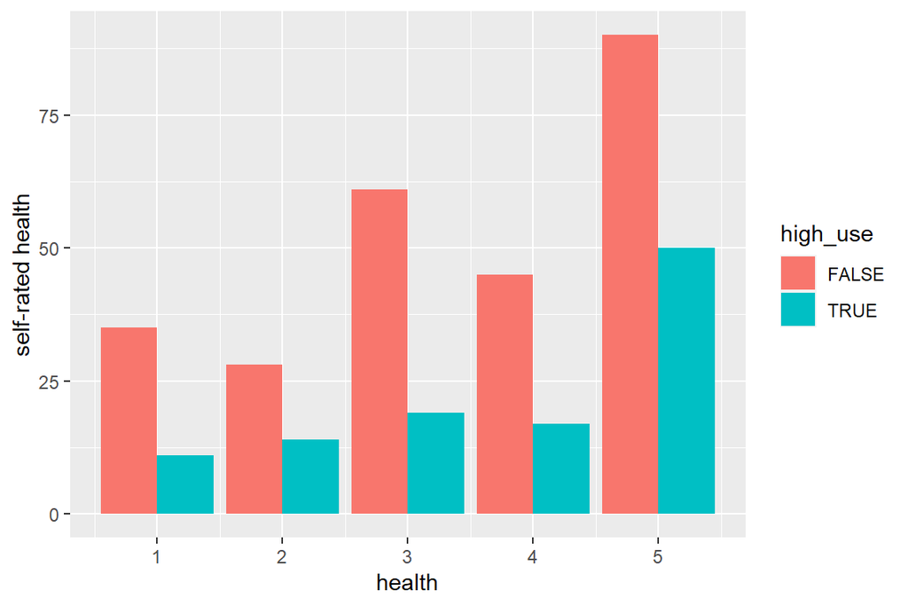

```r
health_bar <- ggplot(data = alc, aes(x=health, fill = high_use))
health_bar + geom_bar(position=position_dodge()) + labs(y="self-rated health")
```

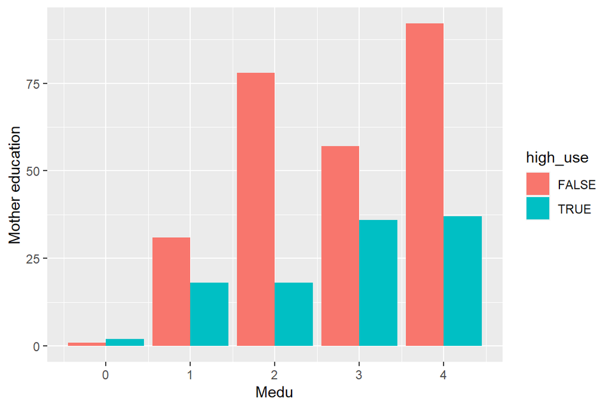

```r
Medu_bar <- ggplot(data = alc, aes(x=Medu, fill = high_use))
Medu_bar + geom_bar(position=position_dodge()) + labs(y="Mother education")
```

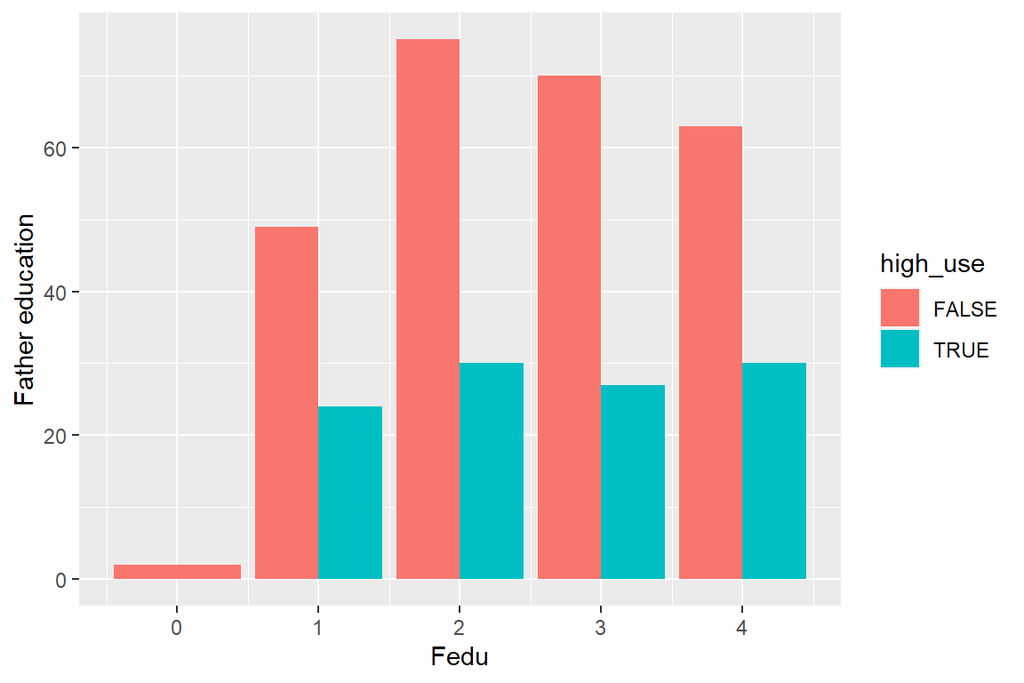

```r
Fedu_bar <- ggplot(data = alc, aes(x=Fedu, fill = high_use))
Fedu_bar + geom_bar(position=position_dodge()) + labs(y="Father education")
```

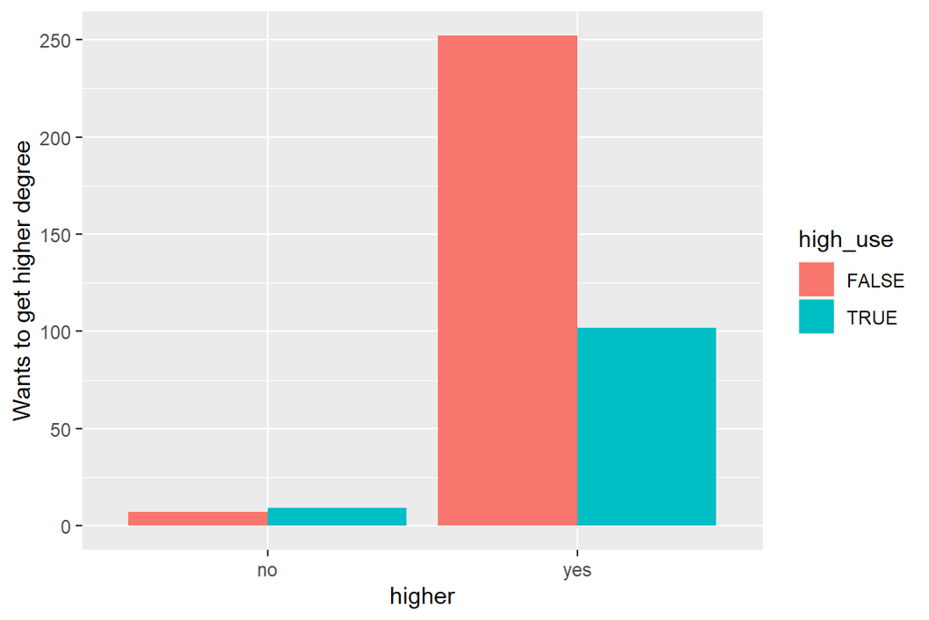

```r
higher_bar <- ggplot(data = alc, aes(x=higher, fill = high_use))
higher_bar + geom_bar(position=position_dodge()) + labs(y="Wants to get higher degree")
```

```r
help(geom_bar)
```

```
## starting httpd help server ... done
```